# vita

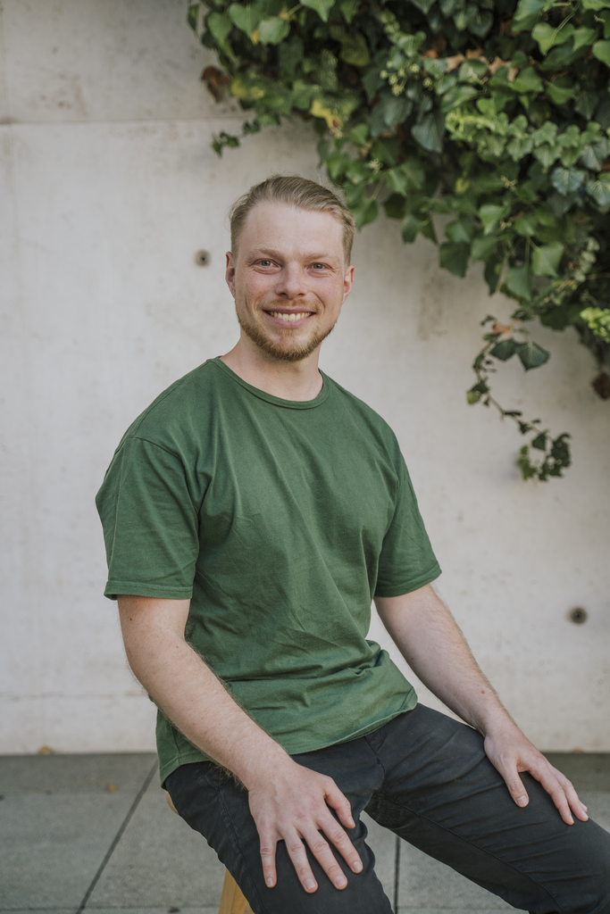

## About me

I have been working as a researcher at the Centre for Media, Communication and Information Research [(ZeMKI)](https://zemki.uni-bremen.de/) at the University of Bremen since April 2020. In the Laboratory for Digital Communication and Information Diversity under the direction of Prof. Dr Cornelius Puschmann, I am dedicated to the systematic investigation of digital media use using quantitative and automated methods (CSS, R, scraping, mobile tracking, etc.).

In September 2024, I defended my doctoral thesis entitled [“Political action and news use of the Fridays for Future Movement in Germany”](https://doi.org/10.26092/elib/3604), in which I investigated the use of political information on smartphones using app tracking, screen recording and surveys.

From December 2017 to February 2020, I worked as a research assistant at the Institute of Communication Science in Jena as part of a DFG project. The research project focused on the investigation of deliberative interactions in online user comments. In my role as a student assistant, I actively supported the data collection and analysis.

Before that, I completed my Master of Arts in Public Communication at the Friedrich Schiller University Jena from October 2017 to February 2020. I had already deepened my interest in social, sociological and political topics during my studies at the University of Passau, where I studied Governance and Public Policy - Political Science from September 2013 to September 2017 and graduated with a Bachelor of Arts.

## Curriculum Vitae

Since April 2020  
**University of Bremen - Centre for Media, Communication and Information Research (ZeMKI)**  
*Research associate*  
Lab: Digital communication and information diversity

October 2017 until February 2020  
**Friedrich Schiller University Jena**  
*Master’s degree in Public Communication, Master of Arts*

September 2013 until September 2017  
**University of Passau**  
*Study programme in the field of Governance and Public Policy - Political Science, Bachelor of Arts degree*

Copyright Picture; 2024 Julia Metz.